# Unit Testing Sharing with Examples

## Hilary Shiue, Digital Preservation Program, NYPL

2023-04-17 Monday

## Sharing objectives

- Basic understanding of testing
- Know about the pytest module
- Know what a testing set up looks like
- Know what a pytest fixture is

## Agenda

- Python testing
- Context of our use
- Development process of lint_er.py
- Development process of flatten_er_metadata_folder.py

## Sidenote

- Please ask questions any time / correct me if I am wrong

# Python testing

## 1. Manual testing

- exploratory testing
  - a form of manual testing without a plan
  - needs a complete list of features to "explore" for
  - re-run/write whenever your code changes

## 2. Automated testing

### planned tests: what parts, in what order, what is expected

### many modules:

- - unittest: built-in in Python
  - nose
  - pytest

# A better introduction:

## [Getting Started With Testing in Python](https://realpython.com/python-testing/) (https://realpython.com/python-testing/)

by Anthony Shaw from Real Python

## These are all automated testings, but different in their scales

### Unit testing

### Integration testing

### Functional testing

## Unit testing

- Perform smaller test; checking one component at a time
- Often check only one method or function
- A kind of white box testing: inspect and verify the inner workings of a software

```python
from pathlib import Path

# The function to test for

def package_has_valid_name(package: Path) -> bool:
    """Top level folder name has to conform to M###_(ER|DI|EM)_####"""
    folder_name = package.name
    match = re.fullmatch(r'M\d+_(ER|DI|EM)_\d+', folder_name)

    if match:
        return True
    else:
        LOGGER.error(f'''{folder_name} does not conform to
        M###_(ER|DI|EM)_####''')
        return False
```

```python
# An example of unit testing, only testing package_has_valid_name function

def test_top_folder_valid_name(good_package):
    """Top level folder name has to conform to M###_(ER|DI|EM)_####"""
    result = lint_er.package_has_valid_name(good_package)

    assert result == True
```

## Integration testing

- Test multiple components at once, e.g. classes, functions and modules
- Check if the data flows correctly between different components
- Usually the individual modules are already tested with unit testing methods

```python
# The function to test for
# the two lists of "...tests" both include multiple functions

def lint_package(package: Path) -> Literal['valid', 'invalid', 'needs review']:
    """Run all linting tests against a package"""
    result = 'valid'

    less_strict_tests = [
        metadata_folder_has_one_or_less_file,
        metadata_file_has_valid_filename,
        package_has_no_hidden_file
    ]

    for test in less_strict_tests:
        if not test(package):
            result = 'needs review'

    strict_tests = [
        package_has_valid_name,
        package_has_valid_subfolder_names,
        objects_folder_has_no_access_folder,
        metadata_folder_is_flat,
        objects_folder_has_file,
        package_has_no_bag,
        package_has_no_zero_bytes_file
    ]

    for test in strict_tests:
        if not test(package):
            result = 'invalid'

    return result
```

```python
# Integration testing - lint_package uses multiple functions

def test_valid_package(good_package):
    """Test that package returns 'valid' when all tests are passed"""
    result = lint_er.lint_package(good_package)

    assert result == 'valid'
```

## Functional Testing

- Test expected behavior for the code
- Check if it fulfills users' expectation
- Only testing part of the specifications

```python
# The function to test for

def main():
    args = parse_args()

    valid = []
    invalid = []
    needs_review = []

    counter = 0

    for package in args.packages:
        counter += 1
        result = lint_package(package)
        if result == 'valid':
            valid.append(package.name)
        elif result == 'invalid':
            invalid.append(package.name)
        else:
            needs_review.append(package.name)
    print(f'\nTotal packages ran: {counter}')
    if valid:
        print(f'''
        The following {len(valid)} packages are valid:
        {", ".join(str(x) for x in valid)}''')
    if invalid:
        print(f'''
        The following {len(invalid)} packages are invalid: {invalid}''')
    if needs_review:
        print(f'''
        The following {len(needs_review)} packages need review.
        They may be passed without change after review: {needs_review}''')
```

```python
# Functional testing - only testing behavior of code
# in this case, a text string from output

def test_lint_valid_package(monkeypatch, good_package, capsys):
    """Run entire script with valid ER"""

    monkeypatch.setattr(
        'sys.argv', [
            '../bin/lint_er.py',
            '--package', str(good_package)
        ]
    )

    lint_er.main()

    stdout = capsys.readouterr().out

    assert f'packages are valid:' in stdout
```

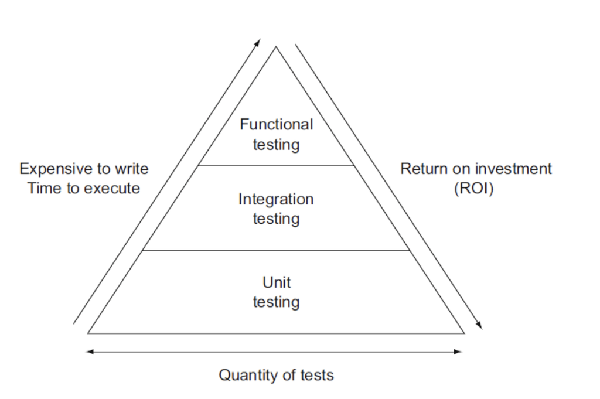

## ROI in automated testing

Once you’ve calculated investment benefits and costs, you can follow the formula to figure out automated testing ROI in three steps:

```
1. Subtract the costs from the benefits (Savings - Cost)
2. Divide the remaining amount by the costs
3. Multiply this by 100
```

## Any questions so far?

## Context of our use

- Creating lint_er.py
  - A linter is a static program that catches errors, bugs and flags potential problems in the source code
  - In our context, lint_er.py is a Python script that confirms each Electronic Record (ER) package conforms to the structure expected by the packaging and ingest processes
  - It lints er packages, hence the script name
  - lint_er.py performs many checks. Therefore, testing the script is ideal

## Development process of lint_er.py

1. List all the issues we would like to catch
2. Determine how serious if the issue exists, namely, throwing a warning or an error (The degree is user-defined)
3. Start writing functions in lint_er.py
4. Start writing test_lint_er.py, utilizing the pytest module

You can jump between writing the functions and tests.  
Writing tests may change how you write functions.

## Common structure of an Electronic Record package

```
path/to/hdd/M18558/M18558_ER_0001
├── metadata
│   └── submissionDocumentation
│       └── M18558_ER_0001.csv
└── objects
    ├── file 01
    ├── file 02
    └── file 03
```

## Issue examples

- Top level folder name has to conform to “M\d+*(ER|DI|EM)*\d+”: error
- Second level folders must have “objects” and “metadata” folder: error
- metadata folder is flat:
  - submissionDocumentation folder exists: error
  - submissionDocumentation folder has file(s) in it: error
- Hidden system files exist in the package: warning

## Pytest setup

There will be two scripts:

1. The script you want, e.g. lint_er.py
2. The test script, e.g. test_lint_er.py

The naming of "test" in the test script is for pytest to do the trick.

```python
# This is one of the functions in lint_er.py

def package_has_valid_name(package: Path) -> bool:
    """Top level folder name has to conform to M###_(ER|DI|EM)_####"""
    folder_name = package.name
    match = re.fullmatch(r'M\d+_(ER|DI|EM)_\d+', folder_name)

    if match:
        return True
    else:
        LOGGER.error(f'{folder_name} does not conform to M###_(ER|DI|EM)_####')
        return False
```

```python
import lint_er as lint_er

import pytest
from pathlib import Path

# This is one of the tests in test_lint_er.py

def test_top_folder_valid_name(tmp_path: Path):
    # tmp_path is a type of fixture from pytest
    """Top level folder name has to conform to M###_(ER|DI|EM)_####"""
    package = tmp_path.joinpath('M12345_ER_0001')
    pkg.mkdir()

    result = lint_er.package_has_valid_name(package)

    assert result == True
```

# We are still missing another result!

## All paths should be walked in unit testing

### So perhaps you'd want to make the original function simpler, potentially easier to test

```python
# This is another test for the package_has_valid_name function

def test_top_folder_invalid_name(tmp_path: Path):
    """Test that package fails function when the top level folder name
    does not conform to the naming convention, M###_(ER|DI|EM)_####"""
    bad_package = tmp_path.joinpath('M12345_0001')
    pkg.mkdir()

    result = lint_er.package_has_valid_name(bad_package)

    assert result == False
```

## Notice when we are repeating the package making process?

### Time to add a pytest fixture

- Fixtures are functions, which will run before each test function to which it is applied
- Fixtures are used to feed some data to the tests
- They can be reused

```python
@pytest.fixture
def good_package(tmp_path: Path):
    pkg = tmp_path.joinpath('M12345_ER_0001')
    f_object = pkg.joinpath('objects')
    f_object.mkdir(parents=True)
    object_filepath = f_object.joinpath('randomFile.txt')
    object_filepath.touch()
    object_filepath.write_bytes(b'some bytes for object')

    f_metadata = pkg.joinpath('metadata')
    f_metadata.mkdir()

    metadata_filepath = f_metadata.joinpath('M12345_ER_0001.csv')
    metadata_filepath.touch()
    metadata_filepath.write_bytes(b'some bytes for metadata')

    return pkg

# Below is what the good_package fixture function will return

#        tmp_path/M12345_ER_0001
#        ├── metadata
#        │   └── M12345_ER_0001.csv
#        │
#        └── objects
# #            └── randomFile.txt
```

```python
# The two previously-mentioned tests would look like this,
# after the pytest fixture is added

def test_top_folder_valid_name(good_package):
    """Top level folder name has to conform to M###_(ER|DI|EM)_####"""
    result = lint_er.package_has_valid_name(good_package)

    assert result == True

def test_top_folder_invalid_name(good_package):
    """Test that package fails function when the top level folder name
    does not conform to the naming convention, M###_(ER|DI|EM)_####"""
    bad_package = good_package
    bad_package = bad_package.rename(bad_package.parent / 'M12345')

    result = lint_er.package_has_valid_name(bad_package)

    assert result == False
```

## Running tests with pytest in Visual Studio Code

# Dealing with all the True or False functions

## In total, ten linting conditions are created in lint_er.py

## Some flag warnings; some flag errors

```python
# lint_package function aggregates all conditions

from typing import Literal

def lint_package(package: Path) -> Literal['valid', 'invalid', 'needs review']:
    """Run all linting tests against a package"""
    result = 'valid'

    less_strict_tests = [
        metadata_folder_has_one_or_less_file,
        metadata_file_has_valid_filename,
        package_has_no_hidden_file
    ]

    for test in less_strict_tests:
        if not test(package):
            result = 'needs review'

    strict_tests = [
        package_has_valid_name,
        package_has_valid_subfolder_names,
        objects_folder_has_no_access_folder,
        metadata_folder_is_flat,
        objects_folder_has_file,
        package_has_no_bag,
        package_has_no_zero_bytes_file
    ]

    for test in strict_tests:
        if not test(package):
            result = 'invalid'

    return result
```

```python
def main():
    args = parse_args()
    _configure_logging(args)

    valid = []
    invalid = []
    needs_review = []

    counter = 0

    for package in args.packages:
        counter += 1
        result = lint_package(package)
        if result == 'valid':
            valid.append(package.name)
        elif result == 'invalid':
            invalid.append(package.name)
        else:
            needs_review.append(package.name)
    print(f'\nTotal packages ran: {counter}')
    if valid:
        print(f'''
        The following {len(valid)} packages are valid:
        {", ".join(str(x) for x in valid)}''')
    if invalid:
        print(f'''
        The following {len(invalid)} packages are invalid: {invalid}''')
    if needs_review:
        print(f'''
        The following {len(needs_review)} packages need review.
        They may be passed without change after review: {needs_review}''')
```

```python
#These are two Functional Tests

def test_lint_valid_package(monkeypatch, good_package, capsys):
    """Run entire script with valid ER"""

    monkeypatch.setattr(
        'sys.argv', [
            '../bin/lint_er.py',
            '--package', str(good_package)
        ]
    )

    lint_er.main()

    stdout = capsys.readouterr().out

    assert f'packages are valid:' in stdout

def test_lint_invalid_package(monkeypatch, good_package, capsys):
    """Run entire script with invalid ER"""

    bad_package = good_package

    objects = bad_package.joinpath('objects')
    bag_folder = objects.joinpath('bagfolder')
    bag_folder.mkdir()
    bag_file = bag_folder.joinpath('bagit.txt')
    bag_file.touch()

    monkeypatch.setattr(
        'sys.argv', [
            '../bin/lint_er.py',
            '--package', str(good_package)
        ]
    )

    lint_er.main()

    stdout = capsys.readouterr().out

    assert f'packages are invalid:' in stdout
```

## The tests are still not exhausted, but good enough for now

### For example:

- we have not tested any logging messages, which would be a kind of functional test
- we have not tested all the "invalid" and "needs reviews" situations

## Development process of flatten_er_metadata_folder.py

### Coming from using lint_er.py: it is flagging that many packages have this issue:

- metadata folder is flat:
  - submissionDocumentation folder exists: error
  - submissionDocumentation folder has file(s) in it: error

### Context of the creation of submissionDocumentation - Archivematica

```
path/to/hdd/M18558/M18558_ER_0001
├── metadata
│   └── submissionDocumentation
│       └── M18558_ER_0001.csv
└── objects
    ├── file 01
    ├── file 02
    └── file 03
```

## flatten_er_metadata_folder.py

1. Good practice script, since it is relatively small
2. Logic of the script:
   1. Go through every package (e.g. M1234_ER_0001)
   2. Get the path for submissionDocumentation
   3. Check if the subissionDocumentation folder has any files
      1. if yes, move it / them up one level
      2. if not, delete the folder
- Delete function should be reusable, as it can delete the folder after moving file(s)
- We don't need to check too many things, since they will be checked by the linter, e.g. file naming convention

```python
# This is one of the functions in flatten_er_metadata_folder.py

def get_submissionDocumentation_path(package: Path) -> Path | None:
    """Get submissionDocumentation folder path under metadata"""
    expected_path = package / 'metadata' / 'submissionDocumentation'

    if expected_path.is_dir():
        return expected_path
    else:
        return None
```

```python
# The fixture for the test
# It is different from good_package fixture for test_lint_er.py,
# because the purpose is different

@pytest.fixture
def common_package(tmp_path: Path):
    pkg = tmp_path.joinpath('M12345_ER_0001')
    f_object = pkg.joinpath('objects')
    f_object.mkdir(parents=True)
    f_metadata = pkg.joinpath('metadata')
    f_metadata.mkdir()

    f_submission = f_metadata.joinpath('submissionDocumentation')
    f_submission.mkdir()
    metadata_filepath = f_submission.joinpath('M12345_ER_0001.csv')
    metadata_filepath.touch()
    metadata_filepath.write_bytes(b'some bytes for metadata')

    return pkg
```

```python
# test_flatten_er_metadata.py
# These are the tests for the get_submissionDocumentation_path function

def test_get_submissionDocumentation_path(common_package):
    """Test that get_submissionDocumentation_path function returns a Path object
    when submissionDocumentation folder exists in the metadata folder"""

    subdoc_path = flatten_md.get_submissionDocumentation_path(common_package)

    result = isinstance(subdoc_path, Path)
    # The isinstance() function returns whether the specified object is of the specified type.

    assert result == True

def test_nonexistent_subdoc_path(common_package):
    """Test that get_submissionDocumentation_path returns None when the submissionDocumentation
    folder does not exist"""

    uncommon_package = common_package
    path_to_remove = uncommon_package / 'metadata' / 'submissionDocumentation'

    shutil.rmtree(path_to_remove)

    subdoc_path = flatten_md.get_submissionDocumentation_path(uncommon_package)

    assert subdoc_path == None
```

```python
# This is one of the functions in flatten_er_metadata_folder.py
# It performs an action and does not return anything

def move_subdoc_files_to_mdfolder(subdoc_file_ls: list) -> None:
    """Move file(s) from the submissionDocumentation folder to the metadata folder"""
    for file in subdoc_file_ls:
        dest = file.parent.parent / file.name
        file.rename(dest)
        LOGGER.info(f'Moving {file} to {dest}')
```

```python
# This is the test for move_subdoc_files_to_mdfolder

def test_move_subdoc_files_to_mdfolder(common_package):
    """Test that move_subdoc_files_to_mdfolder moves file(s) from submissionDocumentation
    up to directly under metadata folder: (1) there's file under metadata;
    (2) there's no file in submissionDocumentation"""

    for subdoc in common_package.rglob('submissionDocumentation'):
        subdoc_file_ls = [x for x in subdoc.iterdir() if x.is_file()]
        # x is Path object that's under subdoc folder AND it is a file, not directory
        # we know this would be M12345_ER_0001.csv because we set the fixture

    flatten_md.move_subdoc_files_to_mdfolder(subdoc_file_ls)

    for md_path in common_package.rglob('metadata'):
        md_file_ls = [x for x in md_path.iterdir() if x.is_file()]
        for subdoc in md_path.glob('submissionDocumentation'):
            subdoc_ls = [x for x in subdoc.iterdir()]

    if len(md_file_ls) > 0 and len(subdoc_ls) == 0:
        result = True
    else:
        result = False

    assert result == True
```

## Do you think this function can be tested more?

# We will be creating more small tools like flatten_er_metadata_folder.py for additional fixes

## Any questions?

### Do you have any script you could test for?

### What are some obstacles / concerns that prevent you from testing your code?

# Resources

- Dziuba, A. (2021, November 17). Doing the math for Test Automation ROI: How to calculate it right. Relevant Software. Retrieved April 17, 2023, from https://relevant.software/blog/test-automation-roi-how-to-calculate-it-right/#What_is_ROI_in_automation_testing
- Imperva. (2020, September 24). What is white box testing: Types & Techniques for code coverage. Learning Center. Retrieved April 13, 2023, from https://www.imperva.com/learn/application-security/white-box-testing/
- Shaw, A. (2023, April 1). Getting started with testing in Python. Real Python. Retrieved April 14, 2023, from https://realpython.com/python-testing/
- Software Testing Help. (2023, March 27). The difference between unit, integration and functional testing. Software Testing Help. Retrieved April 13, 2023, from https://www.softwaretestinghelp.com/the-difference-between-unit-integration-and-functional-testing/
- Test-driven development. NYPL DP Python Workshop. (n.d.). Retrieved April 13, 2023, from https://nypl.github.io/dp-python/lessons/rewrite_ftsh/0_testdrivendevelopment.html
- tutorialspoint. (n.d.). Pytest - fixtures. Tutorials Point. Retrieved April 13, 2023, from https://www.tutorialspoint.com/pytest/pytest_fixtures.htm
- What's the difference between unit, functional, acceptance, and integration tests? Stack Overflow. (1957, November 1). Retrieved April 13, 2023, from https://stackoverflow.com/questions/4904096/whats-the-difference-between-unit-functional-acceptance-and-integration-test